# Writing sample 1

Golding, L.

2023-08-21

## Background:

Human immunodeficiency virus (HIV), the virus causing acquired immunodeficiency syndrome (AIDS), is a preventable infection that can lead to severe, life-long, and often fatal consequences in humans. The HIV virus exists in two main infectious sub-types: HIV-1 and HIV-2. The most common ways that HIV can spread is through open-wounds or cuts where blood from an infected individual transfers to into circulation of another individual usually through injection-drug users who share needles with persons with HIV, anal sex, and, in some cases, vaginal sex. To accurately allocate resources to reduce the spread of HIV, updated monitoring of the main risk groups involved in spreading HIV infections, including persons who inject drugs (PWIDs), men who have sex with men (MSM), and heterosexual individuals are necessitated. Using retrospective data on HIV infections collected by the Epidemiological Surveillance Network of Castilla y León between 2009 and 2022, the etiology of HIV cases were analyzed and the relative risk of AIDS diagnoses among each risk group were compared.

## Objectives:

1. To determine the distributions of age, sex, and risk groups of the reported HIV cases between 2009 and 2022 (restricted to this dataset)
2. To determine the relative risk of AIDS among HIV positive cases in each risk group between 2009 and 2022 (restricted to this dataset)

## Data source

Data were from the Publications Office of the European Union data repository (link: https://data.europa.eu/en). The data set was collected by the “New HIV Infections Register” of the Epidemiological Surveillance Network of Castilla y León (link: https://data.europa.eu/data/datasets/https-datosabiertos-jcyl-es-web-jcyl-set-es-salud-registro-vih-1284868676866?locale=en; retreived 2023-08-21).All downstream uses of the data are in compliance with Creative Commons Attribution 4.0 International (link: https://creativecommons.org/licenses/by/4.0/).

## Methods/Material

### Data wrangling

Data were cleaned using the `dplyr::` package in R (v4.3.0), specifically character values of `Risk Group` and `State of Clinical Infection` were translated to English using Google Translate. Inclusion criteria were adults (>= 18), diagnosed with HIV-1 sub-type infections, and known risk group from Spain. After applying inclusion criteria 981 cases eligible for downstream analyses.

```
## # A tibble: 10 × 9
##    City       Country   Age Sex    `Diagnosis year` `Risk Group`
##    <chr>      <chr>   <dbl> <chr>             <dbl> <chr>
##  1 LEON       ESPANA     32 Male               2009 PWID
##  2 BURGOS     ESPANA     32 Male               2009 HETERO
##  3 AVILA      ESPANA     38 Female             2009 HETERO
##  4 SALAMANCA  ESPANA     40 Male               2009 PWID
##  5 VALLADOLID ESPANA     47 Male               2009 PWID
##  6 BURGOS     ESPANA     44 Female             2009 PWID
##  7 BURGOS     ESPANA     41 Male               2009 MSM/BISEX
##  8 VALLADOLID ESPANA     46 Female             2009 PWID
##  9 LEON       ESPANA     66 Male               2009 HETERO
## 10 VALLADOLID ESPANA     45 Male               2009 PWID
## # ℹ 3 more variables: `State of Clinical Infection` <chr>,
## #   `Viral subtype` <chr>, `Sexual orientation` <chr>
```

### Statistical analysis

To investigate the first objective, arithmetic descriptive statistics were calculated for age, sex, and risk groups as follows:

- Age: median (25/75 quantiles), and visualization of age distribution.
- Sex: proportion of male/female (%; quantiles)
- Risk group: visualize cases per group and relative rates (% of total cases) per year

## Results

### Age and sex distribution of HIV cases by year

In terms of age of risk groups, MSM tended to have a lower age at diagnosis compared to all other groups (33 [27 - 42] N = 470 vs. 43 [35 - 51] N = 511). MSM were also the most represented risk group among cases (47.9% of all cases) followed by HETERO (42.4%), PWID (9.2%), and PWID + MSM (0.5%).

```
## [1] "Mean = 39.35"
```

```
## [1] "SD = 11.64"
```

```
## [1] "Median = 38"
```

```
## [1] "Quantiles = 30 - 48"
```

```
## [1] 37.75
```

```
## [1] "Quantiles = 37 - 40"
```

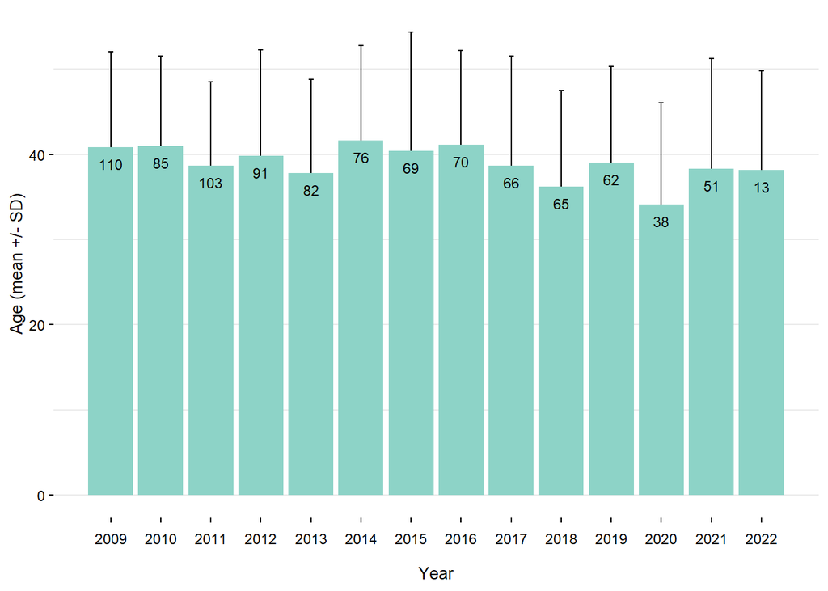

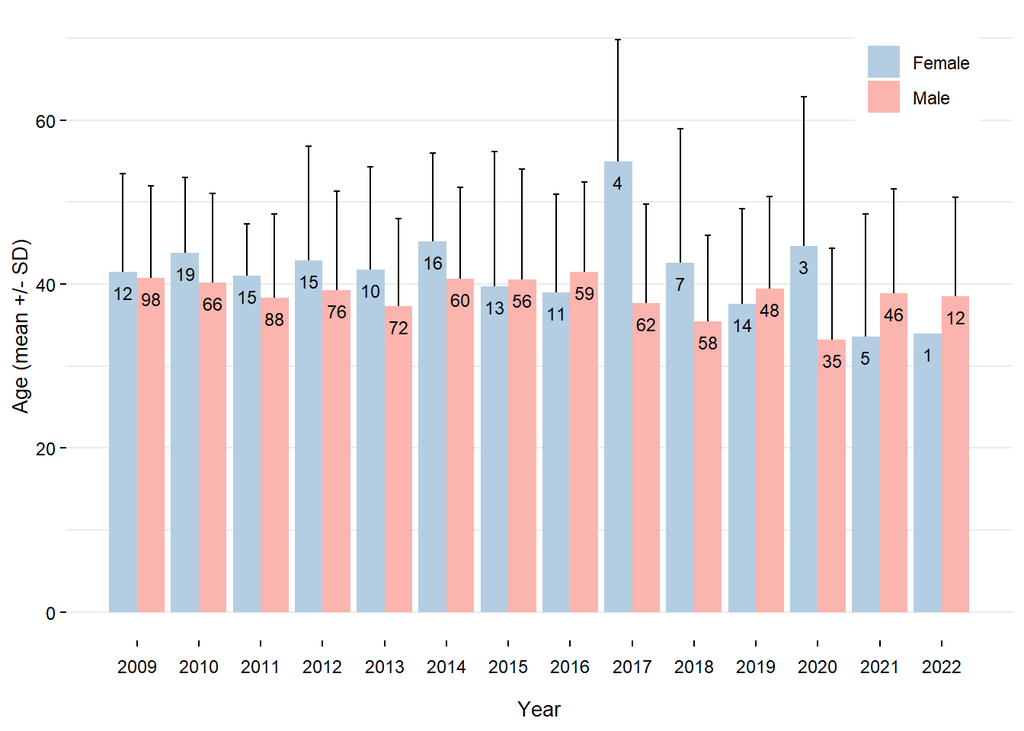

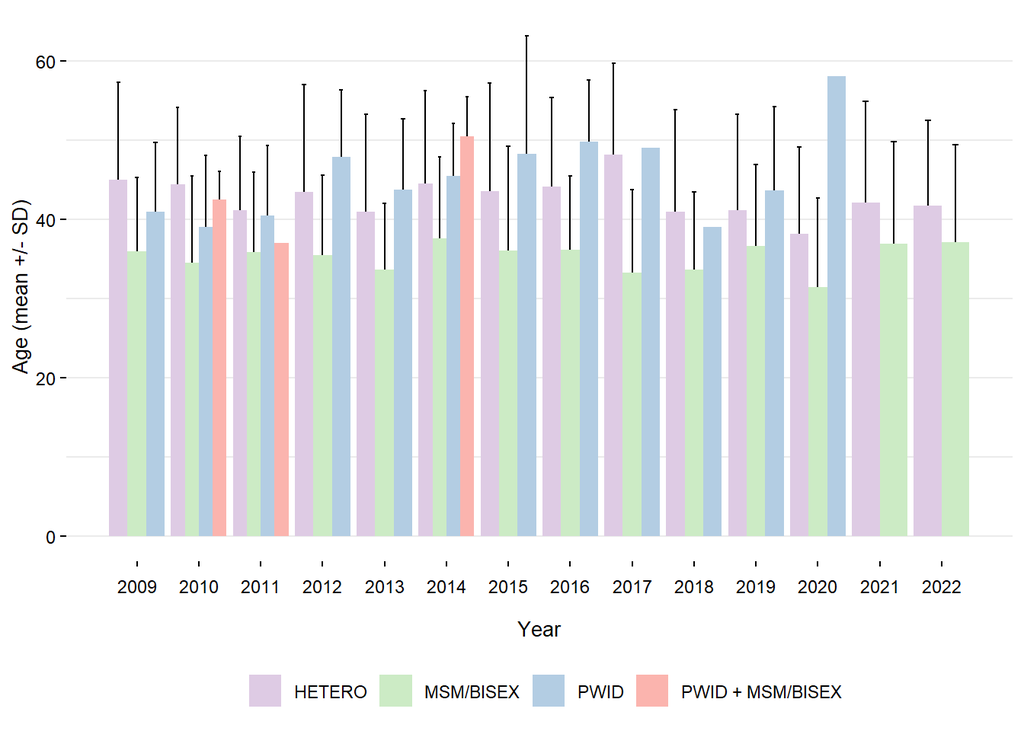

[output not shown]

```
## # A tibble: 1 × 2
##    mean Quantiles
##   <dbl> <chr>
## 1 0.134 0.100452488687783 - 0.182513139034878
```

[output not shown]

### Risk of HIV-1-induced AIDS by risk group

Of the 981 cases, 304 (30.9%) were diagnosed with AIDS, 216 (22.0%) were diagnosed in the early stages of HIV-1, and 461 (46.9%) were diagnosed during the asymptomatic phase of HIV-1 infection. The median age of AIDS, asymptomatic infections, and early-infection diagnoses were 43 (34-51), 37 (29-46), and 35 (27-43), respectively.

PWID + MSM were removed as there were no reported cases of AIDS as the sample was largely under-powered to estimate the true prevalence. Interestingly, although MSM had the highest number of reported cases across each year relative to other groups, MSM had the lowest rate of AIDS diagnoses (22.1% of AIDS cases) compared to HETERO (38.2%) and PWID (45.6%). Comparatively, MSM groups had a statistically significant effect with an estimated 42% reduction in relative risk of AIDS diagnosis relative to the HETERO group (P < 0.0001). PWID had a relatively comparable risk of AIDS to HETERO (P = 0.316).

```
## # A tibble: 6 × 5
## # Groups:   State of Clinical Infection [3]
##   `State of Clinical Infection` Sex    median     n Quantiles
##   <chr>                         <chr>   <dbl> <int> <chr>
## 1 AIDS                          Female   44      58 34.5 - 52
## 2 AIDS                          Male     42     246 34 - 51
## 3 Asymptomatic                  Female   39      67 30 - 47.5
## 4 Asymptomatic                  Male     36     394 29 - 46
## 5 Early-infection               Female   38.5    20 31.25 - 47
## 6 Early-infection               Male     35     196 27 - 43
```

```
## # A tibble: 3 × 3
##   `Risk Group`     n `Proportion of AIDS cases`
##   <chr>        <int>                      <dbl>
## 1 HETERO         416                      0.382
## 2 MSM/BISEX      470                      0.221
## 3 PWID            90                      0.456
```

```
##
## Call:
## glm(formula = AIDS ~ `Risk Group`, family = poisson(), data = data4)
##
## Coefficients:
##                       Estimate Std. Error z value Pr(>|z|)
## (Intercept)            -0.9618     0.0793 -12.128  < 2e-16 ***
## `Risk Group`MSM/BISEX  -0.5466     0.1261  -4.334 1.46e-05 ***
## `Risk Group`PWID        0.1755     0.1752   1.002    0.316
## ---
## Signif. codes:  0 '***' 0.001 '**' 0.01 '*' 0.05 '.' 0.1 ' ' 1
##
## (Dispersion parameter for poisson family taken to be 1)
##
##     Null deviance: 709.19  on 975  degrees of freedom
## Residual deviance: 684.05  on 973  degrees of freedom
## AIC: 1298.1
##
## Number of Fisher Scoring iterations: 5
```

```
##                         Estimate  Std. Error    z value      Pr(>|z|)
## (Intercept)            0.6177885 -0.08253346  0.9999946  0.000000e+00
## `Risk Group`MSM/BISEX  0.4210625 -0.13440263  0.9868867 -1.463384e-05
## `Risk Group`PWID      -0.1918938 -0.19143049 -1.7243221 -3.719561e-01
```

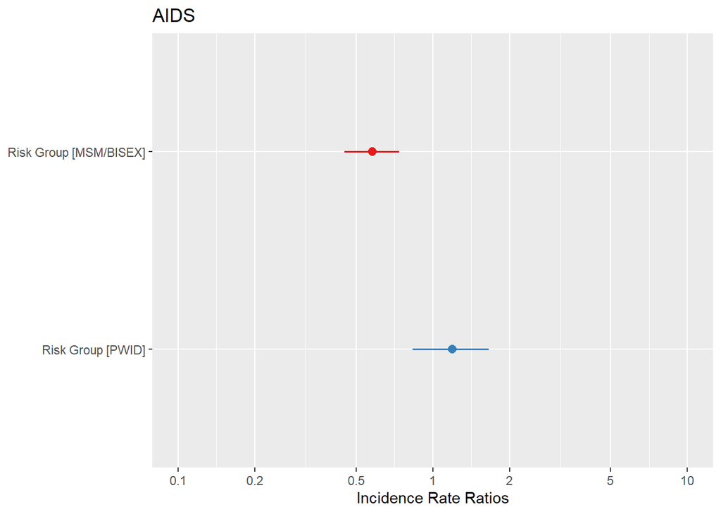